# Risk Factor Analysis

## Outcome Variable

**Outcome Variable:** stunted

## Predictor Variables

**Intervention Variable:** fhtcm

**Adjustment Set:**

unadjusted

## Stratifying Variables

The analysis was stratified on these variable(s):

- agecat
- studyid
- country

## Data Summary

| agecat | studyid | country | fhtcm | stunted | n_cell | n |
| --- | --- | --- | --- | --- | --- | --- |
| Birth | ki1000304b-SAS-CompFeed | INDIA | >=167 cm | 0 | 38 | 102 |
| Birth | ki1000304b-SAS-CompFeed | INDIA | >=167 cm | 1 | 12 | 102 |
| Birth | ki1000304b-SAS-CompFeed | INDIA | <162 cm | 0 | 17 | 102 |
| Birth | ki1000304b-SAS-CompFeed | INDIA | <162 cm | 1 | 6 | 102 |
| Birth | ki1000304b-SAS-CompFeed | INDIA | [162-167) cm | 0 | 20 | 102 |
| Birth | ki1000304b-SAS-CompFeed | INDIA | [162-167) cm | 1 | 9 | 102 |
| Birth | ki1101329-Keneba | GAMBIA | >=167 cm | 0 | 735 | 1165 |
| Birth | ki1101329-Keneba | GAMBIA | >=167 cm | 1 | 37 | 1165 |
| Birth | ki1101329-Keneba | GAMBIA | <162 cm | 0 | 82 | 1165 |
| Birth | ki1101329-Keneba | GAMBIA | <162 cm | 1 | 5 | 1165 |
| Birth | ki1101329-Keneba | GAMBIA | [162-167) cm | 0 | 290 | 1165 |
| Birth | ki1101329-Keneba | GAMBIA | [162-167) cm | 1 | 16 | 1165 |
| Birth | ki1119695-PROBIT | BELARUS | >=167 cm | 0 | 11714 | 12533 |
| Birth | ki1119695-PROBIT | BELARUS | >=167 cm | 1 | 26 | 12533 |
| Birth | ki1119695-PROBIT | BELARUS | <162 cm | 0 | 168 | 12533 |
| Birth | ki1119695-PROBIT | BELARUS | <162 cm | 1 | 0 | 12533 |
| Birth | ki1119695-PROBIT | BELARUS | [162-167) cm | 0 | 622 | 12533 |
| Birth | ki1119695-PROBIT | BELARUS | [162-167) cm | 1 | 3 | 12533 |
| Birth | ki1135781-COHORTS | GUATEMALA | >=167 cm | 0 | 26 | 206 |
| Birth | ki1135781-COHORTS | GUATEMALA | >=167 cm | 1 | 3 | 206 |
| Birth | ki1135781-COHORTS | GUATEMALA | <162 cm | 0 | 111 | 206 |
| Birth | ki1135781-COHORTS | GUATEMALA | <162 cm | 1 | 10 | 206 |
| Birth | ki1135781-COHORTS | GUATEMALA | [162-167) cm | 0 | 54 | 206 |
| Birth | ki1135781-COHORTS | GUATEMALA | [162-167) cm | 1 | 2 | 206 |
| 6 months | ki1000304b-SAS-CompFeed | INDIA | >=167 cm | 0 | 281 | 807 |
| 6 months | ki1000304b-SAS-CompFeed | INDIA | >=167 cm | 1 | 88 | 807 |
| 6 months | ki1000304b-SAS-CompFeed | INDIA | <162 cm | 0 | 129 | 807 |
| 6 months | ki1000304b-SAS-CompFeed | INDIA | <162 cm | 1 | 65 | 807 |
| 6 months | ki1000304b-SAS-CompFeed | INDIA | [162-167) cm | 0 | 168 | 807 |
| 6 months | ki1000304b-SAS-CompFeed | INDIA | [162-167) cm | 1 | 76 | 807 |
| 6 months | ki1000304b-SAS-FoodSuppl | INDIA | >=167 cm | 0 | 64 | 372 |
| 6 months | ki1000304b-SAS-FoodSuppl | INDIA | >=167 cm | 1 | 38 | 372 |
| 6 months | ki1000304b-SAS-FoodSuppl | INDIA | <162 cm | 0 | 72 | 372 |
| 6 months | ki1000304b-SAS-FoodSuppl | INDIA | <162 cm | 1 | 76 | 372 |
| 6 months | ki1000304b-SAS-FoodSuppl | INDIA | [162-167) cm | 0 | 77 | 372 |
| 6 months | ki1000304b-SAS-FoodSuppl | INDIA | [162-167) cm | 1 | 45 | 372 |
| 6 months | ki1101329-Keneba | GAMBIA | >=167 cm | 0 | 849 | 1511 |
| 6 months | ki1101329-Keneba | GAMBIA | >=167 cm | 1 | 130 | 1511 |
| 6 months | ki1101329-Keneba | GAMBIA | <162 cm | 0 | 98 | 1511 |
| 6 months | ki1101329-Keneba | GAMBIA | <162 cm | 1 | 15 | 1511 |
| 6 months | ki1101329-Keneba | GAMBIA | [162-167) cm | 0 | 355 | 1511 |
| 6 months | ki1101329-Keneba | GAMBIA | [162-167) cm | 1 | 64 | 1511 |
| 6 months | ki1119695-PROBIT | BELARUS | >=167 cm | 0 | 10535 | 11895 |
| 6 months | ki1119695-PROBIT | BELARUS | >=167 cm | 1 | 611 | 11895 |
| 6 months | ki1119695-PROBIT | BELARUS | <162 cm | 0 | 131 | 11895 |
| 6 months | ki1119695-PROBIT | BELARUS | <162 cm | 1 | 25 | 11895 |
| 6 months | ki1119695-PROBIT | BELARUS | [162-167) cm | 0 | 529 | 11895 |
| 6 months | ki1119695-PROBIT | BELARUS | [162-167) cm | 1 | 64 | 11895 |
| 6 months | ki1135781-COHORTS | GUATEMALA | >=167 cm | 0 | 31 | 336 |
| 6 months | ki1135781-COHORTS | GUATEMALA | >=167 cm | 1 | 14 | 336 |
| 6 months | ki1135781-COHORTS | GUATEMALA | <162 cm | 0 | 88 | 336 |
| 6 months | ki1135781-COHORTS | GUATEMALA | <162 cm | 1 | 109 | 336 |
| 6 months | ki1135781-COHORTS | GUATEMALA | [162-167) cm | 0 | 61 | 336 |
| 6 months | ki1135781-COHORTS | GUATEMALA | [162-167) cm | 1 | 33 | 336 |
| 24 months | ki1101329-Keneba | GAMBIA | >=167 cm | 0 | 569 | 1297 |
| 24 months | ki1101329-Keneba | GAMBIA | >=167 cm | 1 | 252 | 1297 |
| 24 months | ki1101329-Keneba | GAMBIA | <162 cm | 0 | 63 | 1297 |
| 24 months | ki1101329-Keneba | GAMBIA | <162 cm | 1 | 34 | 1297 |
| 24 months | ki1101329-Keneba | GAMBIA | [162-167) cm | 0 | 216 | 1297 |
| 24 months | ki1101329-Keneba | GAMBIA | [162-167) cm | 1 | 163 | 1297 |
| 24 months | ki1119695-PROBIT | BELARUS | >=167 cm | 0 | 3161 | 3670 |
| 24 months | ki1119695-PROBIT | BELARUS | >=167 cm | 1 | 284 | 3670 |
| 24 months | ki1119695-PROBIT | BELARUS | <162 cm | 0 | 42 | 3670 |
| 24 months | ki1119695-PROBIT | BELARUS | <162 cm | 1 | 11 | 3670 |
| 24 months | ki1119695-PROBIT | BELARUS | [162-167) cm | 0 | 149 | 3670 |
| 24 months | ki1119695-PROBIT | BELARUS | [162-167) cm | 1 | 23 | 3670 |
| 24 months | ki1135781-COHORTS | GUATEMALA | >=167 cm | 0 | 25 | 528 |
| 24 months | ki1135781-COHORTS | GUATEMALA | >=167 cm | 1 | 47 | 528 |
| 24 months | ki1135781-COHORTS | GUATEMALA | <162 cm | 0 | 53 | 528 |
| 24 months | ki1135781-COHORTS | GUATEMALA | <162 cm | 1 | 254 | 528 |
| 24 months | ki1135781-COHORTS | GUATEMALA | [162-167) cm | 0 | 40 | 528 |
| 24 months | ki1135781-COHORTS | GUATEMALA | [162-167) cm | 1 | 109 | 528 |

The following strata were considered:

- agecat: 24 months, studyid: ki1101329-Keneba, country: GAMBIA
- agecat: 24 months, studyid: ki1119695-PROBIT, country: BELARUS
- agecat: 24 months, studyid: ki1135781-COHORTS, country: GUATEMALA
- agecat: 6 months, studyid: ki1000304b-SAS-CompFeed, country: INDIA
- agecat: 6 months, studyid: ki1000304b-SAS-FoodSuppl, country: INDIA
- agecat: 6 months, studyid: ki1101329-Keneba, country: GAMBIA
- agecat: 6 months, studyid: ki1119695-PROBIT, country: BELARUS
- agecat: 6 months, studyid: ki1135781-COHORTS, country: GUATEMALA
- agecat: Birth, studyid: ki1000304b-SAS-CompFeed, country: INDIA
- agecat: Birth, studyid: ki1101329-Keneba, country: GAMBIA
- agecat: Birth, studyid: ki1119695-PROBIT, country: BELARUS
- agecat: Birth, studyid: ki1135781-COHORTS, country: GUATEMALA

### Dropped Strata

Some strata were dropped due to rare outcomes:

- agecat: Birth, studyid: ki1119695-PROBIT, country: BELARUS
- agecat: Birth, studyid: ki1135781-COHORTS, country: GUATEMALA

## Methods Detail

We’re interested in the causal parameters $E[Y_a]$ for all values of $a \in \mathcal{A}$. These parameters represent the mean outcome if, possibly contrary to fact, we intervened to set all units to have $A=a$. Under the randomization and positivity assumptions, these are identified by the statistical parameters $\psi_a=E_W[E_{Y|A,W}(Y|A=a,W)]$. In addition, we’re interested in the mean of $Y$, $E[Y]$ under no intervention (the observed mean). We will estimate these parameters by using SuperLearner to fit the relevant likelihood factors – $E_{Y|A,W}(Y|A=a,W)$ and $p(A=a|W)$, and then updating our likelihood fit using a joint TMLE.

For unadjusted analyses ($W=\{\}$), initial likelihoods were estimated using Lrnr_glm to estimate the simple $E(Y|A)$ and Lrnr_mean to estimate $p(A)$. For adjusted analyses, a small library containing Lrnr_glmnet, Lrnr_xgboost, and Lrnr_mean was used.

Having estimated these parameters, we will then use the delta method to estimate relative risks and attributable risks relative to a prespecified baseline level of $A$.

# Results Detail

## Results Plots

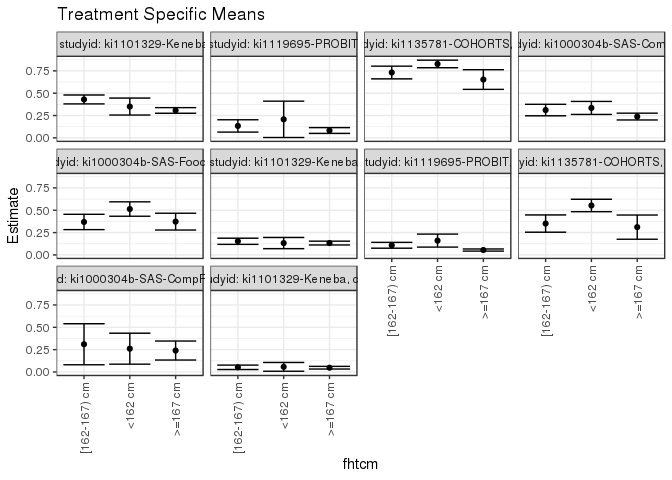

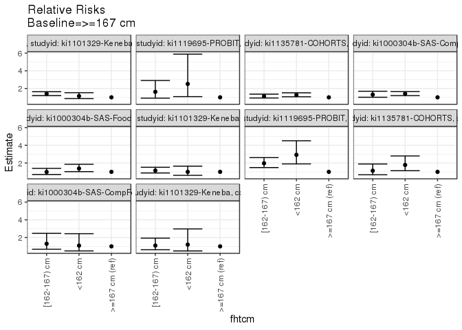

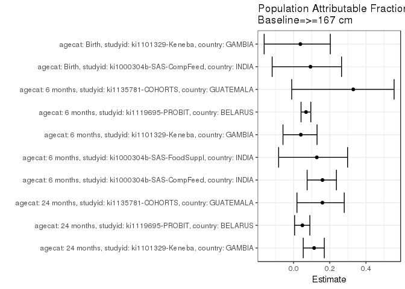

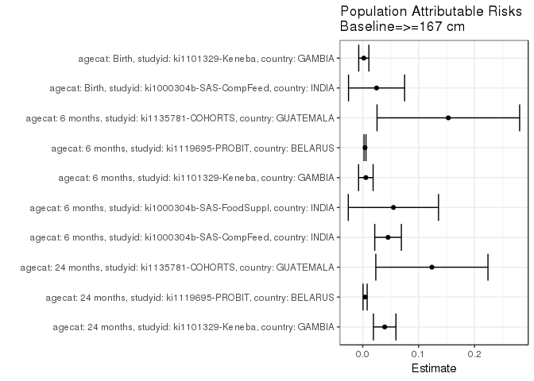

## Results Table

### Parameter: TSM

| agecat | studyid | country | intervention_level | baseline_level | estimate | ci_lower | ci_upper |
| --- | --- | --- | --- | --- | --- | --- | --- |
| Birth | ki1000304b-SAS-CompFeed | INDIA | >=167 cm | NA | 0.2400000 | 0.1335281 | 0.3464719 |
| Birth | ki1000304b-SAS-CompFeed | INDIA | <162 cm | NA | 0.2608696 | 0.0876979 | 0.4340412 |
| Birth | ki1000304b-SAS-CompFeed | INDIA | [162-167) cm | NA | 0.3103448 | 0.0805885 | 0.5401011 |
| Birth | ki1101329-Keneba | GAMBIA | >=167 cm | NA | 0.0479275 | 0.0328526 | 0.0630023 |
| Birth | ki1101329-Keneba | GAMBIA | <162 cm | NA | 0.0574713 | 0.0085444 | 0.1063982 |
| Birth | ki1101329-Keneba | GAMBIA | [162-167) cm | NA | 0.0522876 | 0.0273352 | 0.0772399 |
| 6 months | ki1000304b-SAS-CompFeed | INDIA | >=167 cm | NA | 0.2384824 | 0.2006277 | 0.2763371 |
| 6 months | ki1000304b-SAS-CompFeed | INDIA | <162 cm | NA | 0.3350515 | 0.2623570 | 0.4077461 |
| 6 months | ki1000304b-SAS-CompFeed | INDIA | [162-167) cm | NA | 0.3114754 | 0.2471012 | 0.3758496 |
| 6 months | ki1000304b-SAS-FoodSuppl | INDIA | >=167 cm | NA | 0.3725490 | 0.2785953 | 0.4665028 |
| 6 months | ki1000304b-SAS-FoodSuppl | INDIA | <162 cm | NA | 0.5135135 | 0.4328805 | 0.5941466 |
| 6 months | ki1000304b-SAS-FoodSuppl | INDIA | [162-167) cm | NA | 0.3688525 | 0.2831202 | 0.4545848 |
| 6 months | ki1101329-Keneba | GAMBIA | >=167 cm | NA | 0.1327886 | 0.1115246 | 0.1540525 |
| 6 months | ki1101329-Keneba | GAMBIA | <162 cm | NA | 0.1327434 | 0.0701638 | 0.1953230 |
| 6 months | ki1101329-Keneba | GAMBIA | [162-167) cm | NA | 0.1527446 | 0.1182878 | 0.1872014 |
| 6 months | ki1119695-PROBIT | BELARUS | >=167 cm | NA | 0.0548179 | 0.0428904 | 0.0667454 |
| 6 months | ki1119695-PROBIT | BELARUS | <162 cm | NA | 0.1602564 | 0.0876599 | 0.2328529 |
| 6 months | ki1119695-PROBIT | BELARUS | [162-167) cm | NA | 0.1079258 | 0.0752963 | 0.1405553 |
| 6 months | ki1135781-COHORTS | GUATEMALA | >=167 cm | NA | 0.3111111 | 0.1756479 | 0.4465743 |
| 6 months | ki1135781-COHORTS | GUATEMALA | <162 cm | NA | 0.5532995 | 0.4837730 | 0.6228260 |
| 6 months | ki1135781-COHORTS | GUATEMALA | [162-167) cm | NA | 0.3510638 | 0.2544308 | 0.4476968 |
| 24 months | ki1101329-Keneba | GAMBIA | >=167 cm | NA | 0.3069428 | 0.2753813 | 0.3385042 |
| 24 months | ki1101329-Keneba | GAMBIA | <162 cm | NA | 0.3505155 | 0.2555277 | 0.4455032 |
| 24 months | ki1101329-Keneba | GAMBIA | [162-167) cm | NA | 0.4300792 | 0.3802163 | 0.4799420 |
| 24 months | ki1119695-PROBIT | BELARUS | >=167 cm | NA | 0.0824383 | 0.0499847 | 0.1148919 |
| 24 months | ki1119695-PROBIT | BELARUS | <162 cm | NA | 0.2075472 | 0.0042683 | 0.4108261 |
| 24 months | ki1119695-PROBIT | BELARUS | [162-167) cm | NA | 0.1337209 | 0.0646535 | 0.2027883 |
| 24 months | ki1135781-COHORTS | GUATEMALA | >=167 cm | NA | 0.6527778 | 0.5427050 | 0.7628506 |
| 24 months | ki1135781-COHORTS | GUATEMALA | <162 cm | NA | 0.8273616 | 0.7850453 | 0.8696778 |
| 24 months | ki1135781-COHORTS | GUATEMALA | [162-167) cm | NA | 0.7315436 | 0.6603201 | 0.8027672 |

### Parameter: E(Y)

| agecat | studyid | country | intervention_level | baseline_level | estimate | ci_lower | ci_upper |
| --- | --- | --- | --- | --- | --- | --- | --- |
| Birth | ki1000304b-SAS-CompFeed | INDIA | NA | NA | 0.2647059 | 0.1675094 | 0.3619023 |
| Birth | ki1101329-Keneba | GAMBIA | NA | NA | 0.0497854 | 0.0372905 | 0.0622803 |
| 6 months | ki1000304b-SAS-CompFeed | INDIA | NA | NA | 0.2837670 | 0.2471555 | 0.3203786 |
| 6 months | ki1000304b-SAS-FoodSuppl | INDIA | NA | NA | 0.4274194 | 0.3770801 | 0.4777586 |
| 6 months | ki1101329-Keneba | GAMBIA | NA | NA | 0.1383190 | 0.1209060 | 0.1557320 |
| 6 months | ki1119695-PROBIT | BELARUS | NA | NA | 0.0588483 | 0.0462144 | 0.0714821 |
| 6 months | ki1135781-COHORTS | GUATEMALA | NA | NA | 0.4642857 | 0.4108803 | 0.5176911 |
| 24 months | ki1101329-Keneba | GAMBIA | NA | NA | 0.3461835 | 0.3202819 | 0.3720851 |
| 24 months | ki1119695-PROBIT | BELARUS | NA | NA | 0.0866485 | 0.0534930 | 0.1198040 |
| 24 months | ki1135781-COHORTS | GUATEMALA | NA | NA | 0.7765152 | 0.7409486 | 0.8120817 |

### Parameter: RR

| agecat | studyid | country | intervention_level | baseline_level | estimate | ci_lower | ci_upper |
| --- | --- | --- | --- | --- | --- | --- | --- |
| Birth | ki1000304b-SAS-CompFeed | INDIA | >=167 cm | >=167 cm | 1.0000000 | 1.0000000 | 1.000000 |
| Birth | ki1000304b-SAS-CompFeed | INDIA | <162 cm | >=167 cm | 1.0869565 | 0.4854442 | 2.433801 |
| Birth | ki1000304b-SAS-CompFeed | INDIA | [162-167) cm | >=167 cm | 1.2931034 | 0.6762338 | 2.472690 |
| Birth | ki1101329-Keneba | GAMBIA | >=167 cm | >=167 cm | 1.0000000 | 1.0000000 | 1.000000 |
| Birth | ki1101329-Keneba | GAMBIA | <162 cm | >=167 cm | 1.1991302 | 0.4838511 | 2.971809 |
| Birth | ki1101329-Keneba | GAMBIA | [162-167) cm | >=167 cm | 1.0909733 | 0.6160200 | 1.932117 |
| 6 months | ki1000304b-SAS-CompFeed | INDIA | >=167 cm | >=167 cm | 1.0000000 | 1.0000000 | 1.000000 |
| 6 months | ki1000304b-SAS-CompFeed | INDIA | <162 cm | >=167 cm | 1.4049321 | 1.1967308 | 1.649355 |
| 6 months | ki1000304b-SAS-CompFeed | INDIA | [162-167) cm | >=167 cm | 1.3060730 | 1.0084750 | 1.691491 |
| 6 months | ki1000304b-SAS-FoodSuppl | INDIA | >=167 cm | >=167 cm | 1.0000000 | 1.0000000 | 1.000000 |
| 6 months | ki1000304b-SAS-FoodSuppl | INDIA | <162 cm | >=167 cm | 1.3783784 | 1.0241137 | 1.855191 |
| 6 months | ki1000304b-SAS-FoodSuppl | INDIA | [162-167) cm | >=167 cm | 0.9900777 | 0.7026223 | 1.395136 |
| 6 months | ki1101329-Keneba | GAMBIA | >=167 cm | >=167 cm | 1.0000000 | 1.0000000 | 1.000000 |
| 6 months | ki1101329-Keneba | GAMBIA | <162 cm | >=167 cm | 0.9996596 | 0.6076065 | 1.644682 |
| 6 months | ki1101329-Keneba | GAMBIA | [162-167) cm | >=167 cm | 1.1502846 | 0.8722901 | 1.516874 |
| 6 months | ki1119695-PROBIT | BELARUS | >=167 cm | >=167 cm | 1.0000000 | 1.0000000 | 1.000000 |
| 6 months | ki1119695-PROBIT | BELARUS | <162 cm | >=167 cm | 2.9234336 | 1.8951628 | 4.509620 |
| 6 months | ki1119695-PROBIT | BELARUS | [162-167) cm | >=167 cm | 1.9688068 | 1.4850414 | 2.610163 |
| 6 months | ki1135781-COHORTS | GUATEMALA | >=167 cm | >=167 cm | 1.0000000 | 1.0000000 | 1.000000 |
| 6 months | ki1135781-COHORTS | GUATEMALA | <162 cm | >=167 cm | 1.7784627 | 1.1303897 | 2.798088 |
| 6 months | ki1135781-COHORTS | GUATEMALA | [162-167) cm | >=167 cm | 1.1284195 | 0.6741461 | 1.888805 |
| 24 months | ki1101329-Keneba | GAMBIA | >=167 cm | >=167 cm | 1.0000000 | 1.0000000 | 1.000000 |
| 24 months | ki1101329-Keneba | GAMBIA | <162 cm | >=167 cm | 1.1419571 | 0.8546160 | 1.525909 |
| 24 months | ki1101329-Keneba | GAMBIA | [162-167) cm | >=167 cm | 1.4011706 | 1.2000230 | 1.636034 |
| 24 months | ki1119695-PROBIT | BELARUS | >=167 cm | >=167 cm | 1.0000000 | 1.0000000 | 1.000000 |
| 24 months | ki1119695-PROBIT | BELARUS | <162 cm | >=167 cm | 2.5176056 | 1.0782554 | 5.878327 |
| 24 months | ki1119695-PROBIT | BELARUS | [162-167) cm | >=167 cm | 1.6220726 | 0.9071693 | 2.900362 |
| 24 months | ki1135781-COHORTS | GUATEMALA | >=167 cm | >=167 cm | 1.0000000 | 1.0000000 | 1.000000 |
| 24 months | ki1135781-COHORTS | GUATEMALA | <162 cm | >=167 cm | 1.2674475 | 1.0626830 | 1.511667 |
| 24 months | ki1135781-COHORTS | GUATEMALA | [162-167) cm | >=167 cm | 1.1206626 | 0.9223862 | 1.361560 |

### Parameter: PAR

| agecat | studyid | country | intervention_level | baseline_level | estimate | ci_lower | ci_upper |
| --- | --- | --- | --- | --- | --- | --- | --- |
| Birth | ki1000304b-SAS-CompFeed | INDIA | >=167 cm | NA | 0.0247059 | -0.0254771 | 0.0748889 |
| Birth | ki1101329-Keneba | GAMBIA | >=167 cm | NA | 0.0018579 | -0.0072081 | 0.0109240 |
| 6 months | ki1000304b-SAS-CompFeed | INDIA | >=167 cm | NA | 0.0452847 | 0.0214626 | 0.0691068 |
| 6 months | ki1000304b-SAS-FoodSuppl | INDIA | >=167 cm | NA | 0.0548703 | -0.0258797 | 0.1356203 |
| 6 months | ki1101329-Keneba | GAMBIA | >=167 cm | NA | 0.0055304 | -0.0074869 | 0.0185478 |
| 6 months | ki1119695-PROBIT | BELARUS | >=167 cm | NA | 0.0040304 | 0.0022472 | 0.0058135 |
| 6 months | ki1135781-COHORTS | GUATEMALA | >=167 cm | NA | 0.1531746 | 0.0255534 | 0.2807958 |
| 24 months | ki1101329-Keneba | GAMBIA | >=167 cm | NA | 0.0392407 | 0.0190932 | 0.0593883 |
| 24 months | ki1119695-PROBIT | BELARUS | >=167 cm | NA | 0.0042102 | 0.0005163 | 0.0079040 |
| 24 months | ki1135781-COHORTS | GUATEMALA | >=167 cm | NA | 0.1237374 | 0.0233550 | 0.2241198 |

### Parameter: PAF

| agecat | studyid | country | intervention_level | baseline_level | estimate | ci_lower | ci_upper |
| --- | --- | --- | --- | --- | --- | --- | --- |
| Birth | ki1000304b-SAS-CompFeed | INDIA | >=167 cm | NA | 0.0933333 | -0.1186151 | 0.2651231 |
| Birth | ki1101329-Keneba | GAMBIA | >=167 cm | NA | 0.0373191 | -0.1628844 | 0.2030553 |
| 6 months | ki1000304b-SAS-CompFeed | INDIA | >=167 cm | NA | 0.1595839 | 0.0747613 | 0.2366303 |
| 6 months | ki1000304b-SAS-FoodSuppl | INDIA | >=167 cm | NA | 0.1283759 | -0.0828128 | 0.2983749 |
| 6 months | ki1101329-Keneba | GAMBIA | >=167 cm | NA | 0.0399832 | -0.0587926 | 0.1295441 |
| 6 months | ki1119695-PROBIT | BELARUS | >=167 cm | NA | 0.0684877 | 0.0411052 | 0.0950883 |
| 6 months | ki1135781-COHORTS | GUATEMALA | >=167 cm | NA | 0.3299145 | -0.0105470 | 0.5556718 |
| 24 months | ki1101329-Keneba | GAMBIA | >=167 cm | NA | 0.1133524 | 0.0532410 | 0.1696473 |
| 24 months | ki1119695-PROBIT | BELARUS | >=167 cm | NA | 0.0485892 | 0.0054909 | 0.0898198 |
| 24 months | ki1135781-COHORTS | GUATEMALA | >=167 cm | NA | 0.1593496 | 0.0184476 | 0.2800250 |